# Model_3_Report

### Simulation results for project

We generate plots of simulation result for the project which includes the value of nutrition. As seen in the histogram, the range of net present value (NPV) for mobile game intervention is significantly higher (approx 150-900 million mmk) than the NPV for board game intervention (approx. 10-130 million mmk). This is due to significantly higher expected mobile game subscribers.

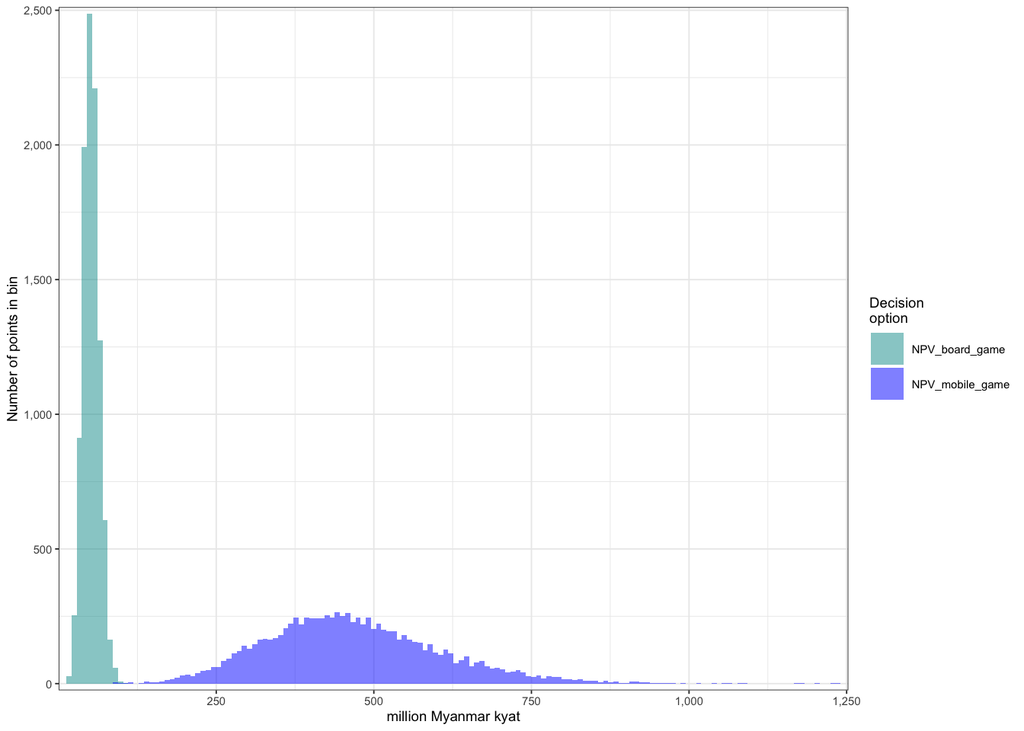

```r
plot_distributions(mcSimulation_object = Game_mc_simulation,
                   vars = c("NPV_mobile_game", "NPV_board_game"),
                   method = 'hist_simple_overlay',
                   x_axis_name = 'million Myanmar kyat',
                   base_size = 7)
```

Here is the result shown in boxplot.

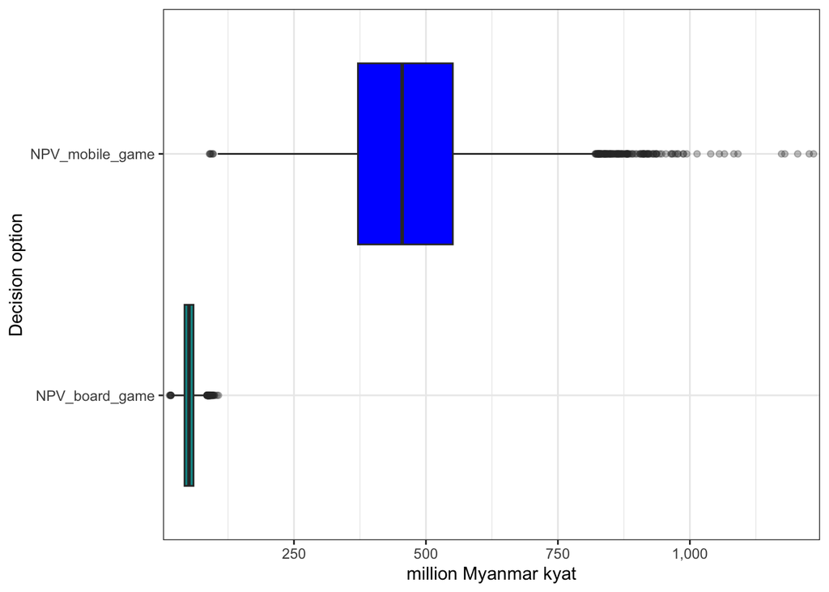

```r
plot_distributions(mcSimulation_object = Game_mc_simulation,
                   vars = c("NPV_mobile_game", "NPV_board_game"),
                   x_axis_name = 'million Myanmar kyat',
                   method = 'boxplot')
```

The predicted cash flow for simulation period of 3 years also confirm mobile game as the better intervention option.

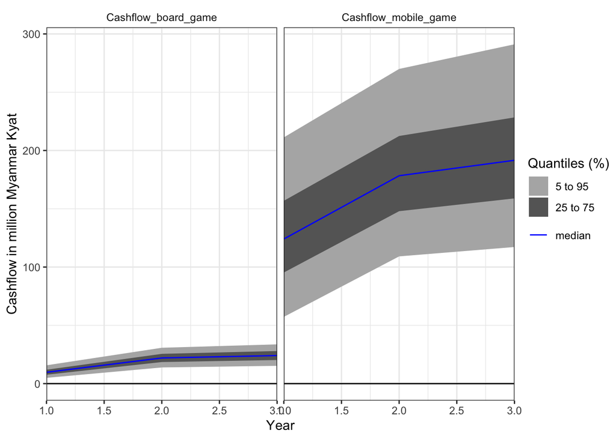

```r
plot_cashflow(mcSimulation_object = Game_mc_simulation,
              cashflow_var_name = c("Cashflow_board_game", "Cashflow_mobile_game"),
              x_axis_name = "Year",
              y_axis_name = "Cashflow in million Myanmar Kyat")
```

### Simulation results for school

We generate the NPV result for school. This informs the school authority of the net profit they can expect from their investment. The school can expect higher NPV for mobile game but there is also a chance of overlap between net profit for mobile game and board game.

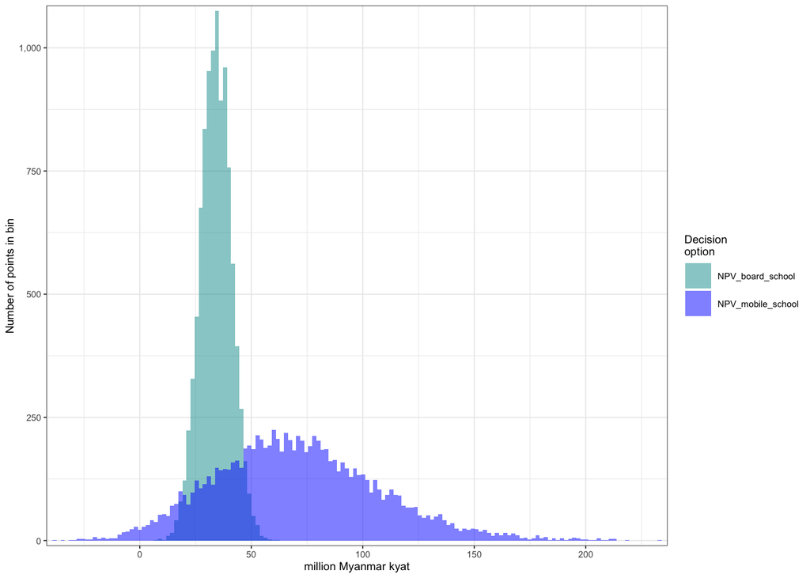

```r
plot_distributions(mcSimulation_object = Game_mc_simulation,
                   vars = c("NPV_mobile_school", "NPV_board_school"),
                   method = 'hist_simple_overlay',
                   x_axis_name = 'million Myanmar kyat',
                   base_size = 7)
```

Here is the result shown in boxplot. The NPV for mobile game intervention still exceeds the NPV for board game intervention, but the difference between them is less pronounced if we consider only the actual monetary benefit for school- exclude the potential healthcare cost saved by individuals and healthcare system.

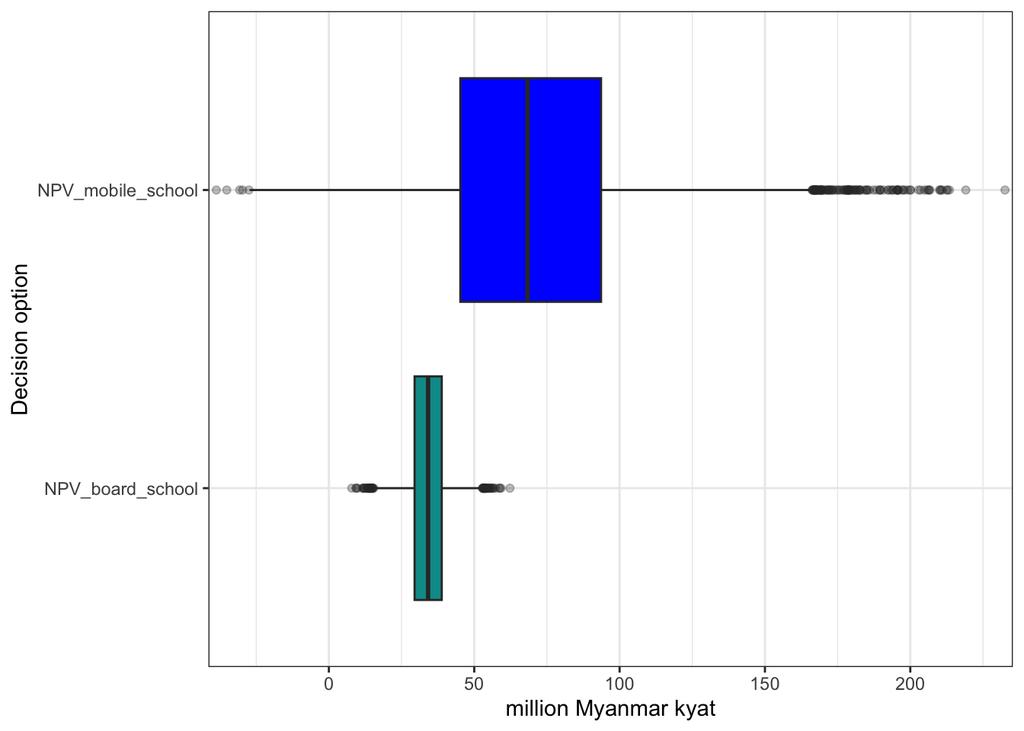

```r
plot_distributions(mcSimulation_object = Game_mc_simulation,
                   vars = c("NPV_mobile_school", "NPV_board_school"),
                   x_axis_name = 'million Myanmar kyat',
                   method = 'boxplot')
```

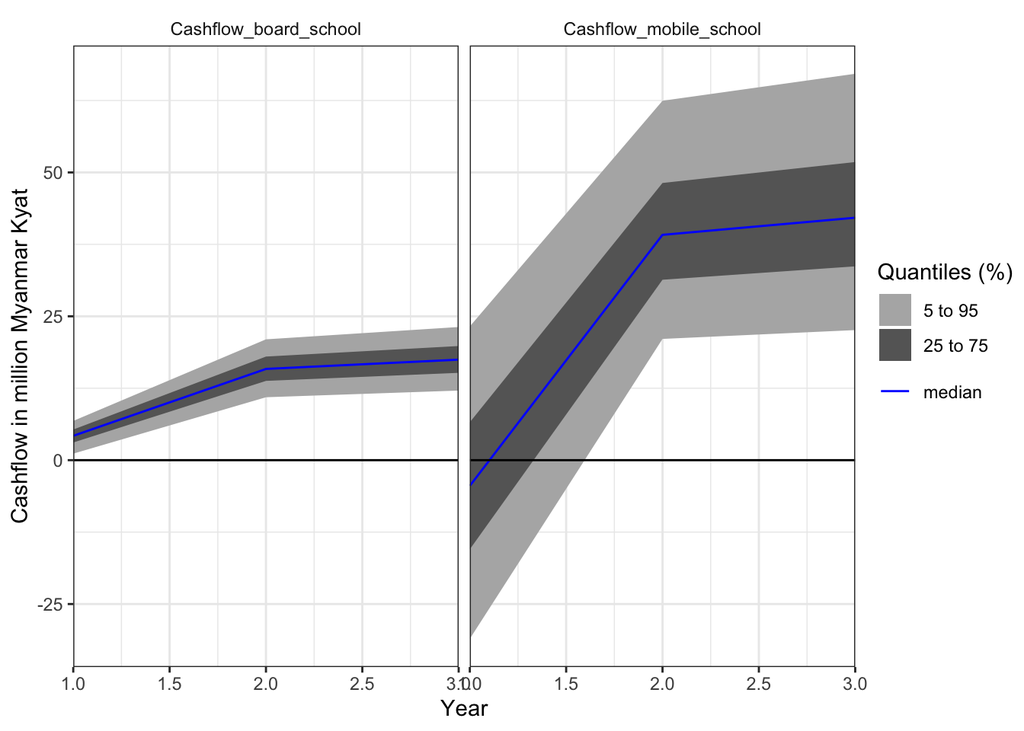

```r
plot_cashflow(mcSimulation_object = Game_mc_simulation,
              cashflow_var_name = c("Cashflow_board_school", "Cashflow_mobile_school"),
              x_axis_name = 'Year',
              y_axis_name = 'Cashflow in million Myanmar Kyat')
```

Next, we do some post-hoc analyses for our model- the EVPI and PLS analyses.

#### EVPI

*(I think EVPI plot would only be generated with positive value- zero EVPI is not positive. So, there maybe something wrong with the model.)*

```r
mcSimulation_table <- data.frame(Game_mc_simulation$x,
                                 Game_mc_simulation$y[1:4])

evpi_mobile <- multi_EVPI(mc = mcSimulation_table, first_out_var = "NPV_mobile_game")
```

```
## [1] "Processing 4 output variables. This can take some time."
## [1] "Output variable 1 (NPV_mobile_game) completed."
## [1] "Output variable 2 (NPV_board_game) completed."
## [1] "Output variable 3 (NPV_mobile_school) completed."
## [1] "Output variable 4 (NPV_board_school) completed."
```

```r
evpi_board <- multi_EVPI(mc = mcSimulation_table, first_out_var = "NPV_board_game")
```

```
## [1] "Processing 3 output variables. This can take some time."
## [1] "Output variable 1 (NPV_board_game) completed."
## [1] "Output variable 2 (NPV_mobile_school) completed."
## [1] "Output variable 3 (NPV_board_school) completed."
```

```r
evpi_mobile_school <- multi_EVPI(mc = mcSimulation_table, first_out_var = "NPV_mobile_school")
```

```
## [1] "Processing 2 output variables. This can take some time."
## [1] "Output variable 1 (NPV_mobile_school) completed."
## [1] "Output variable 2 (NPV_board_school) completed."
```

```r
evpi_board_school <- multi_EVPI(mc = mcSimulation_table, first_out_var = "NPV_board_school")
```

```
## [1] "Processing 1 output variables. This can take some time."
## [1] "Output variable 1 (NPV_board_school) completed."
```

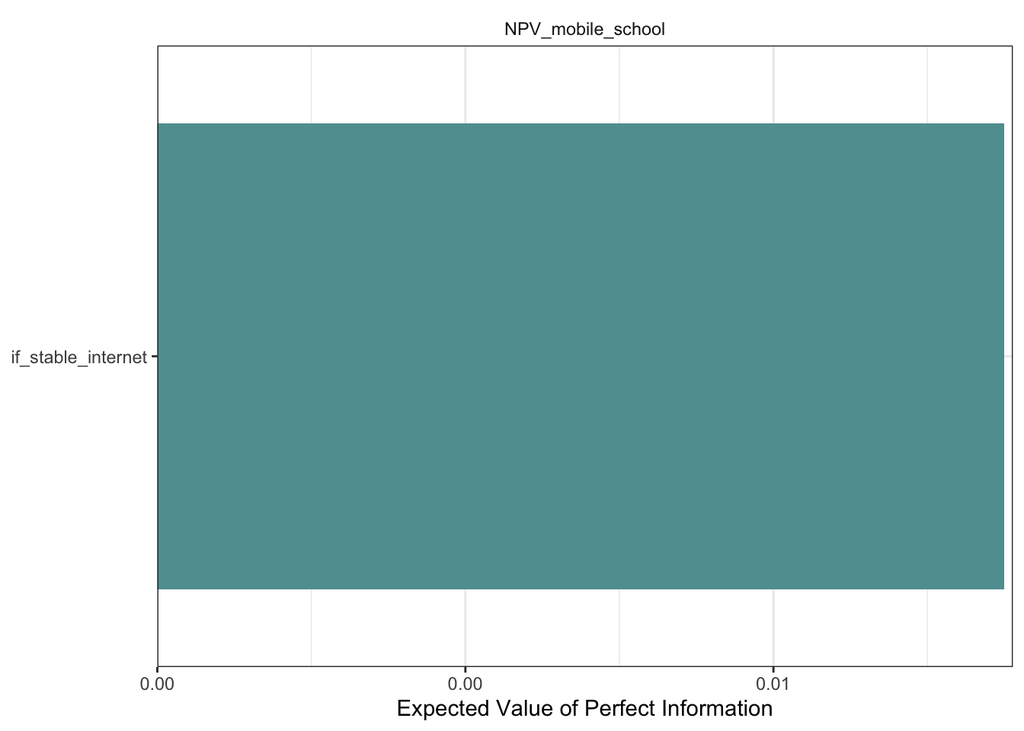

```r
plot_evpi(evpi_mobile, decision_vars = "NPV_mobile_game")
plot_evpi(evpi_board, decision_vars = "NPV_board_game")
plot_evpi(evpi_mobile_school, decision_vars = "NPV_mobile_school")
```

```r
plot_evpi(evpi_board_school, decision_vars = "NPV_board_school")
```

#### PLS

We also identify variable of importance in projection and their direction of impact (positive or negative) on the outcomes using PLS analysis.

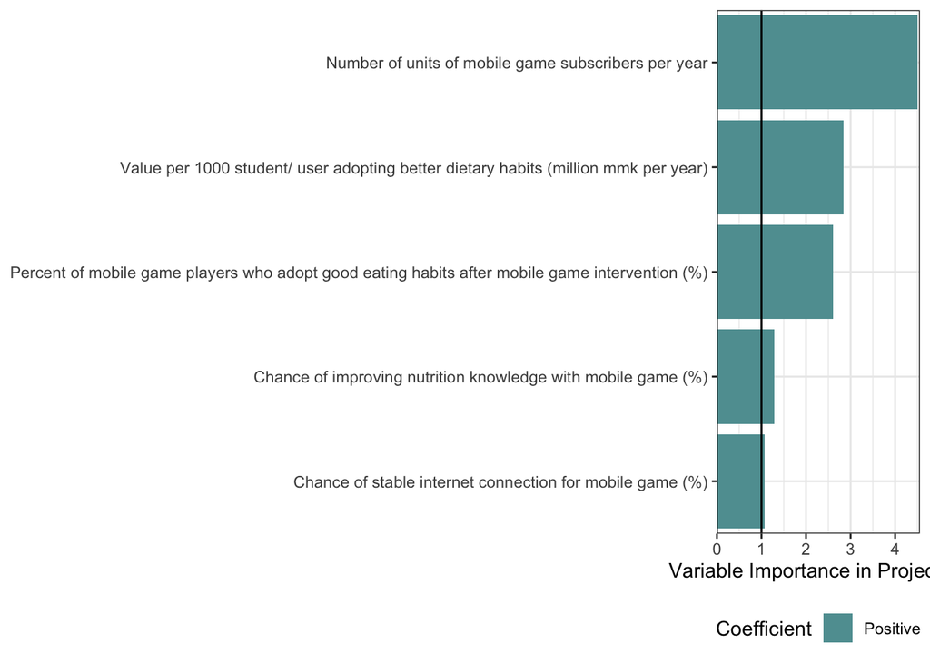

NPV of mobile game intervention for project

```r
pls_result <- plsr.mcSimulation(object = Game_mc_simulation,
                                resultName = names
                                (Game_mc_simulation$y)[1], # NPV_mobile_game
                                ncomp = 1)

plot_pls(pls_result, input_table = input_game, threshold = 0.9)
```

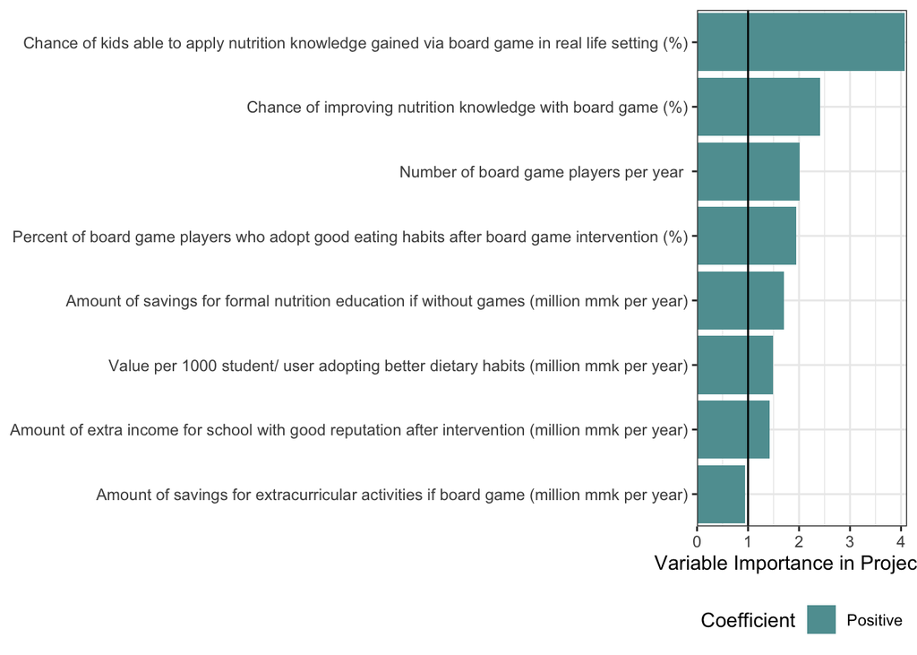

NPV of board game intervention for project

```r
pls_result <- plsr.mcSimulation(object = Game_mc_simulation,
                                resultName = names
                                (Game_mc_simulation$y)[2], # NPV_board_game
                                ncomp = 1)
plot_pls(pls_result, input_table = input_game, threshold = 0.9)
```

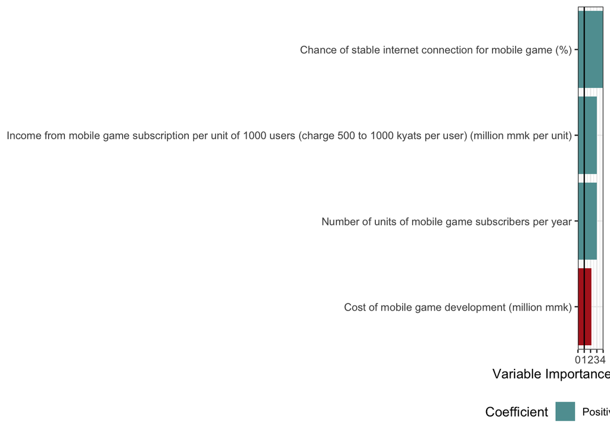

NPV of mobile game intervention for school

```r
pls_result <- plsr.mcSimulation(object = Game_mc_simulation,
                                resultName = names
                                (Game_mc_simulation$y)[3], # NPV_mobile_school
                                ncomp = 1)
plot_pls(pls_result, input_table = input_game, threshold = 0.9)
```

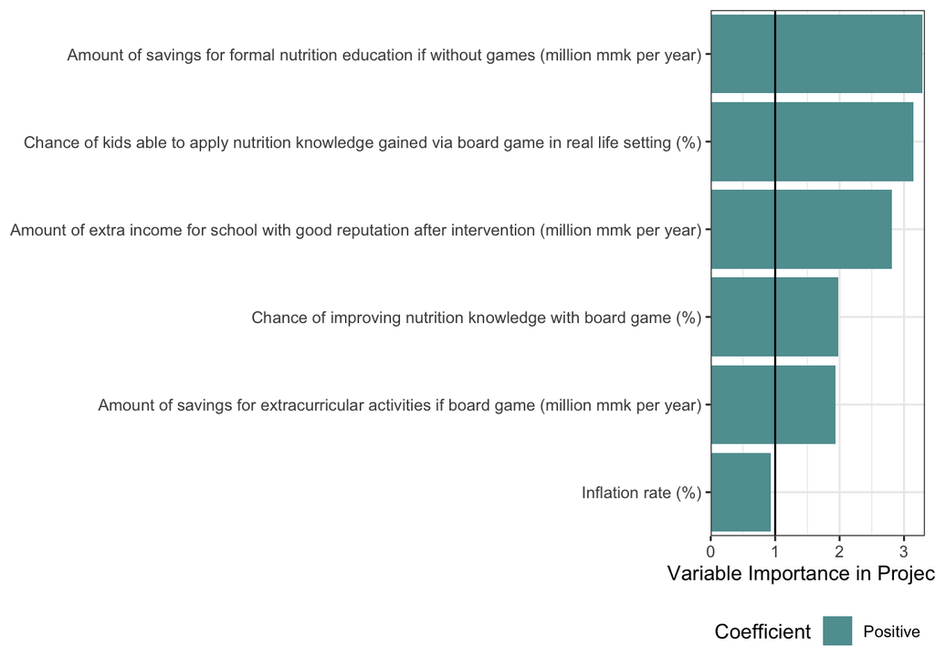

NPV of board game intervention for school

```r
pls_result <- plsr.mcSimulation(object = Game_mc_simulation,
                                resultName = names
                                (Game_mc_simulation$y)[4],
                                ncomp = 1)
plot_pls(pls_result, input_table = input_game, threshold = 0.9) # NPV_board_school
```

#### Cost

Here we calculate total cost for each intervention option.

```r
summary(Game_mc_simulation$y$total_costs_mobile)
```

```
##    Min. 1st Qu.  Median    Mean 3rd Qu.    Max.
##   6.208  34.270  42.667  43.000  51.391  89.162
```

```r
summary(Game_mc_simulation$y$total_costs_board)
```

```
##    Min. 1st Qu.  Median    Mean 3rd Qu.    Max.
##   1.113   4.126   5.017   6.451   8.547  25.274
```

#### Summary

```r
library(gtExtras)
library(svglite)
mcSimulation_summary <- data.frame(Game_mc_simulation$x[2:41],
                                   Game_mc_simulation$y[1:3])

gt_plt_summary(mcSimulation_summary)
```

[output not shown]

### Conclusion

In conclusion, both interventions can bring in profit but the mobile game intervention is significant superior in terms of long-term profit and far-reaching nutrition benefits. However, the school should decide which intervention to invest in, based on their available capital.